# Lukasz Tworzydlo, gd29623

# Multidimensional Data Analysis with R

# [exam with imported dataset (.csv file)]

# 1. Selected data & Student Info

- Used CSV Data
  - Used ‘Artistic Preferences Scale’ dataset from Open-Source Psychometrics Project.
  - Open psychology data [raw data]: (https://openpsychometrics.org/_rawdata/).
- Student Data:
  - Full name: Lukasz Tworzydlo
  - Nr albumu: gd29623
- Additional info:
  - Multidimensional Data Analysis with R
  - Group: INIS6_wszyscy

# 2. Import Data [CSV]

```r
APS_data <- read.delim("~/RProjects/MDA_LukaszTworzydlo_gd29623/APS_Data/APS_data.csv", stringsAsFactors=TRUE)
```

# 3. Load Libraries [FactoMineR, factoextra and ggplot2]

```r
library(FactoMineR)
library(factoextra)
library(ggplot2)
```

# 4. Descriptive Analysis: Tables and Figures with GGPLOT2

```r
summary(APS_data)
```

```
      RA1A            RA1O            RA1I            RA1E               RA2A            RA2O
 Min.   :1.000   Min.   :1.000   Min.   : 1.00   Min.   :      16   Min.   :1.000   Min.   :1.000
 1st Qu.:2.000   1st Qu.:1.000   1st Qu.: 8.00   1st Qu.:    3134   1st Qu.:2.000   1st Qu.:1.000
 Median :3.000   Median :2.000   Median :16.00   Median :    4625   Median :3.000   Median :2.000
 Mean   :2.803   Mean   :1.501   Mean   :15.54   Mean   :    9005   Mean   :3.161   Mean   :1.501
 3rd Qu.:4.000   3rd Qu.:2.000   3rd Qu.:23.00   3rd Qu.:    7336   3rd Qu.:4.000   3rd Qu.:2.000
 Max.   :5.000   Max.   :2.000   Max.   :30.00   Max.   :26663735   Max.   :5.000   Max.   :2.000
      RA2I            RA2E                RA3A            RA3O            RA3I            RA3E
 Min.   : 1.00   Min.   :        7   Min.   :1.000   Min.   :1.000   Min.   : 1.00   Min.   :       7
 1st Qu.: 8.00   1st Qu.:     2955   1st Qu.:2.000   1st Qu.:1.000   1st Qu.: 8.00   1st Qu.:    3039
 Median :16.00   Median :     4203   Median :3.000   Median :1.000   Median :16.00   Median :    4366
 Mean   :15.44   Mean   :    19360   Mean   :2.883   Mean   :1.499   Mean   :15.55   Mean   :    8078
 3rd Qu.:23.00   3rd Qu.:     6418   3rd Qu.:4.000   3rd Qu.:2.000   3rd Qu.:23.00   3rd Qu.:    6725
 Max.   :30.00   Max.   :234185876   Max.   :5.000   Max.   :2.000   Max.   :30.00   Max.   :11413375
      RA4A            RA4O            RA4I            RA4E              RA5A            RA5O
 Min.   :1.000   Min.   :1.000   Min.   : 1.00   Min.   :      9   Min.   :1.000   Min.   :1.000
 1st Qu.:2.000   1st Qu.:1.000   1st Qu.: 8.00   1st Qu.:   2871   1st Qu.:2.000   1st Qu.:1.000
 Median :2.000   Median :1.000   Median :16.00   Median :   4229   Median :3.000   Median :2.000
 Mean   :2.652   Mean   :1.496   Mean   :15.52   Mean   :   7098   Mean   :3.039   Mean   :1.502
 3rd Qu.:4.000   3rd Qu.:2.000   3rd Qu.:23.00   3rd Qu.:   6733   3rd Qu.:4.000   3rd Qu.:2.000
 Max.   :5.000   Max.   :2.000   Max.   :30.00   Max.   :5696148   Max.   :5.000   Max.   :2.000
      RA5I            RA5E               RA6A            RA6O            RA6I            RA6E
 Min.   : 1.00   Min.   :       7   Min.   :1.000   Min.   :1.000   Min.   : 1.00   Min.   :  -5099
 1st Qu.: 8.00   1st Qu.:    2945   1st Qu.:2.000   1st Qu.:1.000   1st Qu.: 8.00   1st Qu.:   2885
 Median :15.00   Median :    4221   Median :3.000   Median :1.000   Median :15.00   Median :   4111
 Mean   :15.46   Mean   :   11130   Mean   :3.004   Mean   :1.497   Mean   :15.47   Mean   :   6817
 3rd Qu.:23.00   3rd Qu.:    6553   3rd Qu.:4.000   3rd Qu.:2.000   3rd Qu.:23.00   3rd Qu.:   6342
 Max.   :30.00   Max.   :38630807   Max.   :5.000   Max.   :2.000   Max.   :30.00   Max.   :7442322
      RA7A            RA7O            RA7I            RA7E              RA8A            RA8O
 Min.   :1.000   Min.   :1.000   Min.   : 1.00   Min.   : -61867   Min.   :1.000   Min.   :1.000
 1st Qu.:2.000   1st Qu.:1.000   1st Qu.: 8.00   1st Qu.:   2923   1st Qu.:2.000   1st Qu.:1.000
 Median :3.000   Median :1.000   Median :16.00   Median :   4248   Median :3.000   Median :2.000
 Mean   :2.833   Mean   :1.496   Mean   :15.56   Mean   :   7001   Mean   :3.267   Mean   :1.501
 3rd Qu.:4.000   3rd Qu.:2.000   3rd Qu.:23.00   3rd Qu.:   6753   3rd Qu.:4.000   3rd Qu.:2.000
 Max.   :5.000   Max.   :2.000   Max.   :30.00   Max.   :4790544   Max.   :5.000   Max.   :2.000
      RA8I            RA8E              LP1A            LP1O            LP1I            LP1E
 Min.   : 1.00   Min.   : -79336   Min.   :1.000   Min.   :1.000   Min.   : 1.00   Min.   :     20
 1st Qu.: 8.00   1st Qu.:   3085   1st Qu.:2.000   1st Qu.:1.000   1st Qu.: 8.00   1st Qu.:   3158
 Median :16.00   Median :   4410   Median :3.000   Median :2.000   Median :15.00   Median :   4536
 Mean   :15.58   Mean   :   7087   Mean   :3.136   Mean   :1.505   Mean   :15.46   Mean   :   6936
```

[output cut: 142 more lines]

```
    screenh            hand         religion       orientation         race           voted
 Min.   :   0.0   Min.   :0.00   Min.   : 0.000   Min.   :0.000   Min.   : 0.00   Min.   :0.000
 1st Qu.: 667.0   1st Qu.:1.00   1st Qu.: 1.000   1st Qu.:1.000   1st Qu.:60.00   1st Qu.:1.000
 Median : 768.0   Median :1.00   Median : 2.000   Median :1.000   Median :60.00   Median :2.000
 Mean   : 814.6   Mean   :1.16   Mean   : 4.412   Mean   :1.655   Mean   :52.07   Mean   :1.618
 3rd Qu.: 900.0   3rd Qu.:1.00   3rd Qu.: 7.000   3rd Qu.:2.000   3rd Qu.:60.00   3rd Qu.:2.000
 Max.   :2561.0   Max.   :3.00   Max.   :12.000   Max.   :5.000   Max.   :70.00   Max.   :2.000
    married        familysize               major
 Min.   :0.000   Min.   :0.000e+00             :7703
 1st Qu.:1.000   1st Qu.:2.000e+00   psychology: 432
 Median :1.000   Median :2.000e+00   English   : 404
 Mean   :1.221   Mean   :1.223e+05   Psychology: 397
 3rd Qu.:1.000   3rd Qu.:3.000e+00   Art       : 256
 Max.   :3.000   Max.   :2.147e+09   (Other)   :9379
 [ reached getOption("max.print") -- omitted 1 row ]
```

```r
head(APS_data)
```

|  | RA1A | RA1O | RA1I | RA1E | RA2A | RA2O | RA2I | RA2E | RA3A | RA3O | RA3I | RA3E | RA4A | RA4O | RA4I | RA4E | RA5A | RA5O | RA5I | RA5E | RA6A | RA6O | RA6I | RA6E | RA7A | RA7O | RA7I | RA7E | RA8A | … |
| --- | --- | --- | --- | --- | --- | --- | --- | --- | --- | --- | --- | --- | --- | --- | --- | --- | --- | --- | --- | --- | --- | --- | --- | --- | --- | --- | --- | --- | --- | --- |
| 1 | 1 | 1 | 18 | 1950 | 2 | 1 | 5 | 2838 | 3 | 1 | 22 | 2117 | 1 | 1 | 24 | 2796 | 2 | 1 | 21 | 4282 | 2 | 2 | 2 | 2924 | 1 | 1 | 4 | 4288 | 2 | … |
| 2 | 5 | 2 | 14 | 5414 | 5 | 1 | 10 | 3802 | 4 | 1 | 22 | 3921 | 2 | 2 | 2 | 7019 | 3 | 1 | 26 | 2961 | 4 | 2 | 19 | 6239 | 2 | 1 | 13 | 3149 | 5 | … |
| 3 | 1 | 1 | 16 | 2300 | 1 | 2 | 13 | 2836 | 1 | 2 | 26 | 2780 | 1 | 1 | 9 | 4695 | 1 | 2 | 15 | 2588 | 1 | 1 | 12 | 5476 | 1 | 1 | 21 | 2443 | 1 | … |
| 4 | 4 | 1 | 2 | 24280 | 5 | 1 | 17 | 3055 | 4 | 2 | 3 | 9921 | 5 | 1 | 27 | 4620 | 5 | 1 | 13 | 12540 | 5 | 2 | 8 | 5712 | 5 | 2 | 10 | 8374 | 4 | … |
| 5 | 5 | 2 | 28 | 6839 | 4 | 2 | 7 | 14119 | 3 | 1 | 13 | 7569 | 2 | 2 | 6 | 4223 | 4 | 2 | 11 | 11048 | 5 | 1 | 12 | 22556 | 3 | 1 | 5 | 5215 | 3 | … |
| 6 | 2 | 1 | 13 | 2853 | 3 | 1 | 15 | 2590 | 3 | 1 | 8 | 3942 | 4 | 1 | 19 | 6062 | 5 | 1 | 7 | 6963 | 4 | 1 | 14 | 4566 | 3 | 2 | 29 | 7457 | 5 | … |

## 4.1. Frequency Table for Categorical Variables & Descriptive Statistics for Numeric Variables

Frequency table for a categorical variable: gender 0 (no answer); 1 (female); 2 (male); 3 (other)

```r
table(APS_data$gender)
```

```
    0     1     2     3
   70  6243 11604   658
```

```r
summary(APS_data$gender)
```

```
   Min. 1st Qu.  Median    Mean 3rd Qu.    Max.
  0.000   1.000   2.000   1.692   2.000   3.000
```

Frequency table for a categorical variable: education 0 (no answer); 1 (less than high school); 2 (high school); 3 (university degree); 4 (graduate degree)

```r
table(APS_data$education)
```

```
   0    1    2    3    4
 262 3226 7549 5168 2370
```

```r
summary(APS_data$education)
```

```
   Min. 1st Qu.  Median    Mean 3rd Qu.    Max.
  0.000   2.000   2.000   2.332   3.000   4.000
```

Frequency table for a categorical variable: religion 0 (no answer); 1 (Agnostic); 2 (Atheist); 3 (Buddhist); 4 (Christian [Catholic]); 5 (Christian [Mormon]); 6 (Christian [Protestant]); 7 (Christian [Other]); 8 (Hindu); 9 (Jewish); 10 (Muslim); 11 (Sikh); 12 (Other)

```r
table(APS_data$religion)
```

```
   0    1    2    3    4    5    6    7    8    9   10   11   12
 430 4314 4549  381 2096  143 1542 1864  264  212  681   19 2080
```

```r
summary(APS_data$religion)
```

```
   Min. 1st Qu.  Median    Mean 3rd Qu.    Max.
  0.000   1.000   2.000   4.412   7.000  12.000
```

Frequency table for a categorical variable: TIPI9 (calm, emotionally stable) 0 = No answer 1 = Disagree strongly 2 = Disagree moderately 3 = Disagree a little 4 = Neither agree nor disagree 5 = Agree a little 6 = Agree moderately 7 = Agree strongly

```r
table(APS_data$TIPI9)
```

```
   0    1    2    3    4    5    6    7
 119 1427 2100 3120 2398 3584 3641 2186
```

```r
summary(APS_data$TIPI9)
```

```
   Min. 1st Qu.  Median    Mean 3rd Qu.    Max.
  0.000   3.000   5.000   4.288   6.000   7.000
```

## 4.2. Figures with GGPLOT2

**Histogram** of TIPI9: TIPI9 Calm, emotionally stable. 0 = No answer 1 = Disagree strongly 2 = Disagree moderately 3 = Disagree a little 4 = Neither agree nor disagree 5 = Agree a little 6 = Agree moderately 7 = Agree strongly

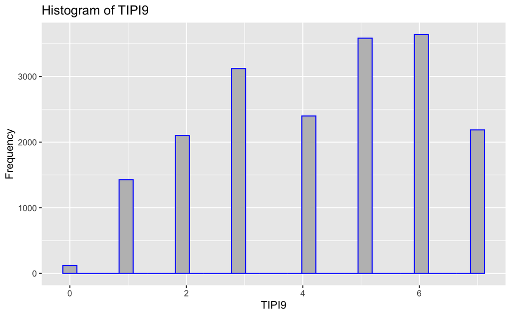

```r
ggplot(data = APS_data) +
  geom_histogram(mapping = aes(x = TIPI9), bins = 30, fill = "grey", color = "blue") +
  ggtitle("Histogram of TIPI9") +
  xlab("TIPI9") +
  ylab("Frequency")
```

**Histogram** of religion: 0 (no answer); 1 (Agnostic); 2 (Atheist); 3 (Buddhist); 4 (Christian [Catholic]); 5 (Christian [Mormon]); 6 (Christian [Protestant]); 7 (Christian [Other]); 8 (Hindu); 9 (Jewish); 10 (Muslim); 11 (Sikh); 12 (Other)

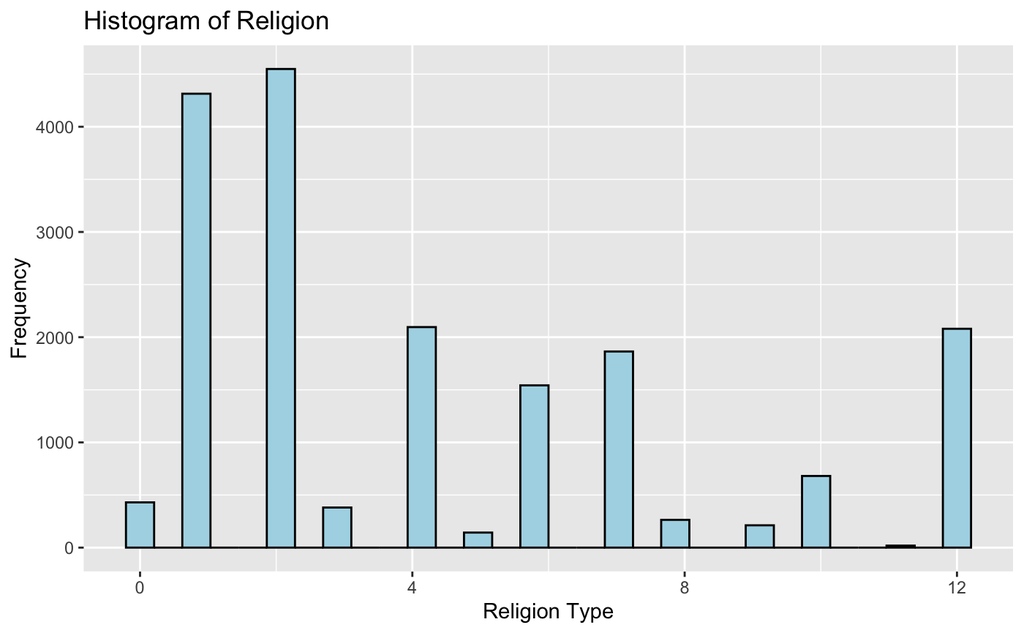

```r
ggplot(data = APS_data) +
  geom_histogram(mapping = aes(x = religion), bins = 30, fill = "lightblue", color = "black") +
  ggtitle("Histogram of Religion") +
  xlab("Religion Type") +
  ylab("Frequency")
```

- Conclusions *Histogram of religion*
  - this Histogram shows the distribution of different religions among respondents, highlighting the diversity of religious beliefs

**Bar Plot** of Gender: 0 (no answer); 1 (female); 2 (male); 3 (other)

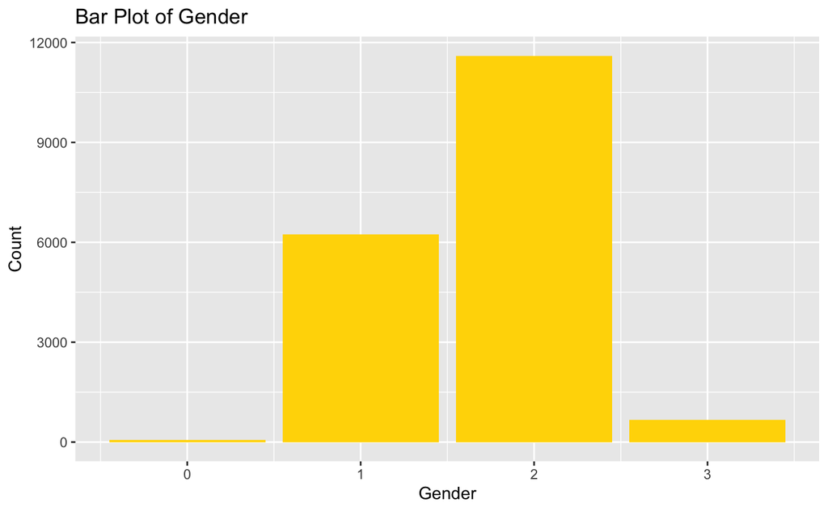

```r
ggplot(data = APS_data) +
  geom_bar(mapping = aes(x = gender), fill = "gold") +
  ggtitle("Bar Plot of Gender") +
  xlab("Gender") +
  ylab("Count")
```

- Conclusions *Bar Plot of Gender*
  - this Bar Plot visualizes the count of each gender category, confirming the higher number of male respondents

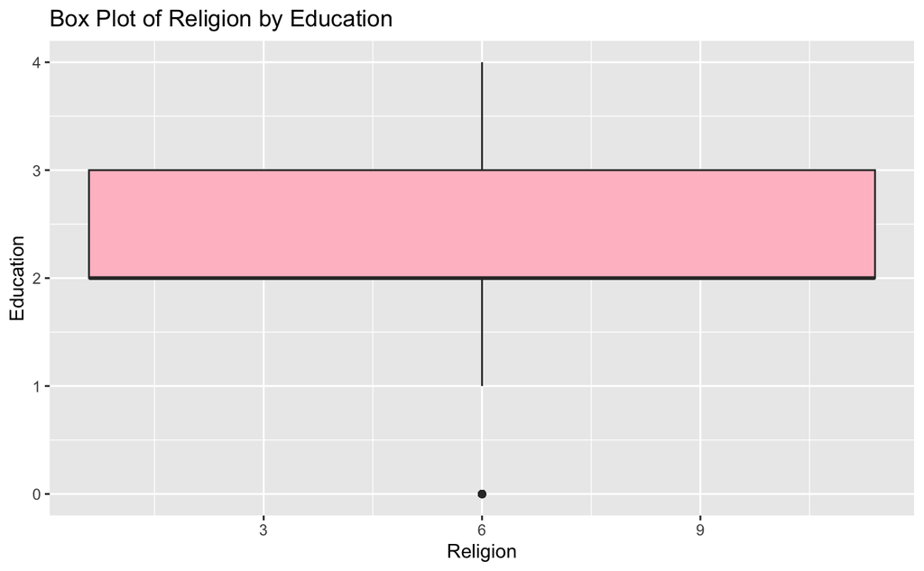

```r
ggplot(data = APS_data) +
  geom_boxplot(mapping = aes(x = religion, y = education), fill = "pink") +
  ggtitle("Box Plot of Religion by Education") +
  xlab("Religion") +
  ylab("Education")
```

**Scatter Plot** for Two Numeric Variables TIPI4 Anxious, easily upset. TIPI9 Calm, emotionally stable.

0 = No answer 1 = Disagree strongly 2 = Disagree moderately 3 = Disagree a little 4 = Neither agree nor disagree 5 = Agree a little 6 = Agree moderately 7 = Agree strongly

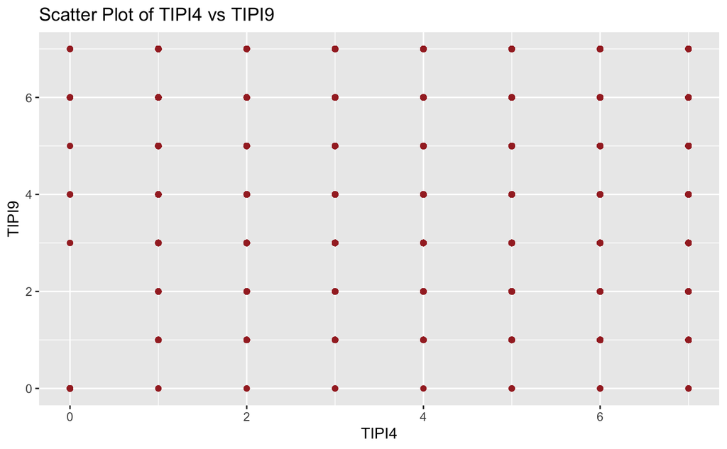

```r
ggplot(data = APS_data) +
  geom_point(mapping = aes(x = TIPI4, y = TIPI9), color = "brown") +
  ggtitle("Scatter Plot of TIPI4 vs TIPI9") +
  xlab("TIPI4") +
  ylab("TIPI9")
```

- Conclusions *Scatter Plot for Two Numeric Variables*
  - this Scatter Plot visualizes the relationship between TIPI4 (Anxious, easily upset) and TIPI9 (Calm, emotionally stable)

# 5.Principal Component Analysis

APS Data Preparation for PCA

```r
numeric_variables <- APS_data[, grep("^RA|^LP|^MF|^V", names(APS_data))]
```

```r
res.pca <- PCA(numeric_variables, graph = F)
```

## 5.1. Summary of the Results

```r
summary(res.pca)
```

```
Call:
PCA(X = numeric_variables, graph = F)


Eigenvalues
                       Dim.1   Dim.2   Dim.3   Dim.4   Dim.5   Dim.6   Dim.7   Dim.8   Dim.9  Dim.10  Dim.11
Variance               4.651   4.316   3.681   3.310   2.355   1.851   1.675   1.263   1.186   1.167   1.156
% of var.              3.420   3.174   2.707   2.434   1.732   1.361   1.232   0.929   0.872   0.858   0.850
Cumulative % of var.   3.420   6.594   9.301  11.735  13.466  14.827  16.059  16.987  17.859  18.717  19.567
                      Dim.12  Dim.13  Dim.14  Dim.15  Dim.16  Dim.17  Dim.18  Dim.19  Dim.20  Dim.21  Dim.22
Variance               1.155   1.144   1.142   1.135   1.125   1.123   1.121   1.117   1.114   1.108   1.101
% of var.              0.849   0.841   0.840   0.835   0.827   0.826   0.825   0.821   0.819   0.815   0.809
Cumulative % of var.  20.416  21.257  22.097  22.932  23.759  24.585  25.409  26.230  27.049  27.864  28.674
                      Dim.23  Dim.24  Dim.25  Dim.26  Dim.27  Dim.28  Dim.29  Dim.30  Dim.31  Dim.32  Dim.33
Variance               1.098   1.095   1.092   1.090   1.087   1.084   1.081   1.081   1.072   1.070   1.067
% of var.              0.807   0.805   0.803   0.801   0.799   0.797   0.795   0.795   0.788   0.787   0.784
Cumulative % of var.  29.481  30.286  31.089  31.890  32.689  33.487  34.281  35.076  35.864  36.651  37.435
                      Dim.34  Dim.35  Dim.36  Dim.37  Dim.38  Dim.39  Dim.40  Dim.41  Dim.42  Dim.43  Dim.44
Variance               1.064   1.061   1.059   1.056   1.054   1.054   1.047   1.046   1.044   1.040   1.036
% of var.              0.782   0.780   0.779   0.776   0.775   0.775   0.770   0.769   0.768   0.765   0.762
Cumulative % of var.  38.218  38.998  39.777  40.553  41.328  42.103  42.873  43.642  44.410  45.174  45.936
                      Dim.45  Dim.46  Dim.47  Dim.48  Dim.49  Dim.50  Dim.51  Dim.52  Dim.53  Dim.54  Dim.55
Variance               1.035   1.029   1.029   1.027   1.024   1.022   1.021   1.019   1.014   1.013   1.010
% of var.              0.761   0.757   0.756   0.755   0.753   0.752   0.751   0.749   0.746   0.745   0.742
Cumulative % of var.  46.697  47.454  48.210  48.965  49.718  50.470  51.221  51.970  52.716  53.461  54.204
                      Dim.56  Dim.57  Dim.58  Dim.59  Dim.60  Dim.61  Dim.62  Dim.63  Dim.64  Dim.65  Dim.66
Variance               1.008   1.005   1.004   1.000   0.997   0.994   0.990   0.985   0.983   0.982   0.979
% of var.              0.741   0.739   0.738   0.735   0.733   0.731   0.728   0.725   0.723   0.722   0.720
Cumulative % of var.  54.945  55.684  56.422  57.157  57.891  58.622  59.349  60.074  60.797  61.519  62.239
                      Dim.67  Dim.68  Dim.69  Dim.70  Dim.71  Dim.72  Dim.73  Dim.74  Dim.75  Dim.76  Dim.77
Variance               0.975   0.972   0.970   0.968   0.966   0.964   0.959   0.958   0.954   0.953   0.949
% of var.              0.717   0.715   0.713   0.712   0.710   0.709   0.705   0.704   0.702   0.701   0.698
Cumulative % of var.  62.956  63.670  64.384  65.095  65.805  66.514  67.219  67.924  68.625  69.326  70.023
                      Dim.78  Dim.79  Dim.80  Dim.81  Dim.82  Dim.83  Dim.84  Dim.85  Dim.86  Dim.87  Dim.88
Variance               0.945   0.941   0.939   0.936   0.933   0.930   0.928   0.924   0.922   0.917   0.916
% of var.              0.695   0.692   0.690   0.688   0.686   0.684   0.682   0.680   0.678   0.674   0.674
Cumulative % of var.  70.719  71.411  72.101  72.789  73.475  74.159  74.841  75.521  76.199  76.873  77.546
                      Dim.89  Dim.90  Dim.91  Dim.92  Dim.93  Dim.94  Dim.95  Dim.96  Dim.97  Dim.98  Dim.99
Variance               0.909   0.905   0.904   0.899   0.894   0.887   0.872   0.868   0.860   0.854   0.802
% of var.              0.668   0.666   0.665   0.661   0.657   0.652   0.641   0.639   0.632   0.628   0.590
```

[output cut: 28 more lines]

```
9     | 10.471 | -0.020  0.000  0.000 | -1.187  0.002  0.013 | -0.894  0.001  0.007 |
10    |  9.374 | -0.117  0.000  0.000 | -1.575  0.003  0.028 |  0.543  0.000  0.003 |

Variables (the 10 first)
         Dim.1    ctr   cos2    Dim.2    ctr   cos2    Dim.3    ctr   cos2
RA1A  |  0.247  1.315  0.061 |  0.509  5.997  0.259 | -0.098  0.258  0.010 |
RA1O  |  0.002  0.000  0.000 |  0.012  0.004  0.000 | -0.005  0.001  0.000 |
RA1I  |  0.013  0.004  0.000 | -0.002  0.000  0.000 |  0.003  0.000  0.000 |
RA1E  |  0.003  0.000  0.000 |  0.007  0.001  0.000 | -0.001  0.000  0.000 |
RA2A  |  0.218  1.023  0.048 |  0.475  5.237  0.226 | -0.124  0.416  0.015 |
RA2O  | -0.005  0.001  0.000 |  0.003  0.000  0.000 | -0.003  0.000  0.000 |
RA2I  | -0.006  0.001  0.000 |  0.003  0.000  0.000 | -0.006  0.001  0.000 |
RA2E  |  0.004  0.000  0.000 | -0.006  0.001  0.000 | -0.003  0.000  0.000 |
RA3A  |  0.227  1.109  0.052 |  0.496  5.691  0.246 | -0.070  0.132  0.005 |
RA3O  | -0.018  0.007  0.000 |  0.006  0.001  0.000 |  0.007  0.001  0.000 |
```

## 5.2. Analyze the Eigen Values

```r
eigenvalues <- round(res.pca$eig, 3)
eigenvalues
```

```
         eigenvalue percentage of variance cumulative percentage of variance
comp 1        4.651                  3.420                             3.420
comp 2        4.316                  3.174                             6.594
comp 3        3.681                  2.707                             9.301
comp 4        3.310                  2.434                            11.735
comp 5        2.355                  1.732                            13.466
comp 6        1.851                  1.361                            14.827
comp 7        1.675                  1.232                            16.059
comp 8        1.263                  0.929                            16.987
comp 9        1.186                  0.872                            17.859
comp 10       1.167                  0.858                            18.717
comp 11       1.156                  0.850                            19.567
comp 12       1.155                  0.849                            20.416
comp 13       1.144                  0.841                            21.257
comp 14       1.142                  0.840                            22.097
comp 15       1.135                  0.835                            22.932
comp 16       1.125                  0.827                            23.759
comp 17       1.123                  0.826                            24.585
comp 18       1.121                  0.825                            25.409
comp 19       1.117                  0.821                            26.230
comp 20       1.114                  0.819                            27.049
comp 21       1.108                  0.815                            27.864
comp 22       1.101                  0.809                            28.674
comp 23       1.098                  0.807                            29.481
comp 24       1.095                  0.805                            30.286
comp 25       1.092                  0.803                            31.089
comp 26       1.090                  0.801                            31.890
comp 27       1.087                  0.799                            32.689
comp 28       1.084                  0.797                            33.487
comp 29       1.081                  0.795                            34.281
comp 30       1.081                  0.795                            35.076
comp 31       1.072                  0.788                            35.864
comp 32       1.070                  0.787                            36.651
comp 33       1.067                  0.784                            37.435
comp 34       1.064                  0.782                            38.218
comp 35       1.061                  0.780                            38.998
comp 36       1.059                  0.779                            39.777
comp 37       1.056                  0.776                            40.553
comp 38       1.054                  0.775                            41.328
comp 39       1.054                  0.775                            42.103
```

[output cut: 82 more lines]

```
comp 122      0.542                  0.398                            95.538
comp 123      0.537                  0.395                            95.932
comp 124      0.519                  0.381                            96.314
comp 125      0.512                  0.376                            96.690
comp 126      0.509                  0.375                            97.065
comp 127      0.501                  0.368                            97.433
comp 128      0.486                  0.358                            97.791
comp 129      0.480                  0.353                            98.143
comp 130      0.473                  0.347                            98.491
comp 131      0.459                  0.338                            98.828
comp 132      0.443                  0.326                            99.154
comp 133      0.430                  0.316                            99.471
comp 134      0.399                  0.293                            99.764
comp 135      0.321                  0.236                           100.000
comp 136      0.000                  0.000                           100.000
```

## 5.3. Visualization of the Eigen Values

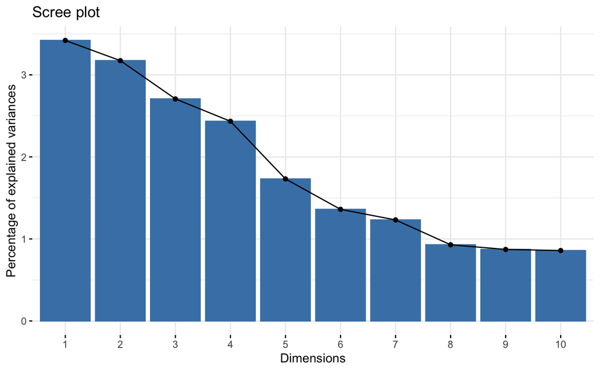

```r
fviz_screeplot(res.pca)
```

## 5.4. Variables Plot (Variables Dimension - Circle of Correlation)

```r
round(res.pca$var$coord, 3)
```

```
       Dim.1  Dim.2  Dim.3  Dim.4  Dim.5
RA1A   0.247  0.509 -0.098 -0.269 -0.031
RA1O   0.002  0.012 -0.005  0.001 -0.003
RA1I   0.013 -0.002  0.003  0.015 -0.012
RA1E   0.003  0.007 -0.001  0.008 -0.007
RA2A   0.218  0.475 -0.124 -0.437 -0.025
RA2O  -0.005  0.003 -0.003  0.004  0.017
RA2I  -0.006  0.003 -0.006 -0.002 -0.001
RA2E   0.004 -0.006 -0.003  0.026 -0.007
RA3A   0.227  0.496 -0.070 -0.404  0.003
RA3O  -0.018  0.006  0.007 -0.012  0.011
RA3I   0.004  0.004 -0.003 -0.016 -0.009
RA3E   0.005  0.008 -0.016  0.006  0.003
RA4A   0.292  0.538 -0.095 -0.372  0.034
RA4O  -0.020  0.001 -0.018 -0.013 -0.012
RA4I  -0.006  0.002  0.007 -0.010  0.004
RA4E  -0.001  0.020 -0.006 -0.009 -0.021
RA5A   0.164  0.480 -0.098 -0.422 -0.078
RA5O  -0.006  0.019  0.012 -0.001  0.013
RA5I  -0.004  0.009  0.012 -0.019  0.001
RA5E  -0.004  0.010 -0.012  0.014 -0.008
RA6A   0.251  0.525 -0.087 -0.347 -0.036
RA6O  -0.012 -0.006  0.010  0.015  0.015
RA6I   0.011  0.007  0.014 -0.011 -0.012
RA6E   0.017  0.008  0.002 -0.014  0.022
RA7A   0.281  0.552 -0.045 -0.404 -0.004
RA7O   0.006  0.006  0.013  0.014  0.032
RA7I  -0.001 -0.012 -0.003 -0.014 -0.002
RA7E   0.008  0.000  0.005 -0.002  0.002
RA8A   0.218  0.426 -0.023 -0.453 -0.012
RA8O  -0.009 -0.001  0.005  0.008 -0.013
RA8I   0.002  0.002  0.007  0.017 -0.017
RA8E  -0.002 -0.007 -0.009 -0.018 -0.009
LP1A   0.230  0.316  0.471  0.279 -0.028
LP1O  -0.001  0.009 -0.011 -0.006  0.016
LP1I  -0.005 -0.004 -0.010  0.001 -0.019
LP1E  -0.008 -0.005 -0.023  0.004 -0.011
LP2A   0.220  0.332  0.461  0.266 -0.004
LP2O  -0.006  0.003  0.002  0.008 -0.003
LP2I   0.011  0.003  0.001 -0.009  0.000
```

[output cut: 82 more lines]

```
VCL2   0.602 -0.316  0.021 -0.056  0.049
VCL3   0.393 -0.158 -0.050  0.066  0.515
VCL4   0.625 -0.398  0.035 -0.129 -0.288
VCL5   0.581 -0.344  0.039 -0.089 -0.087
VCL6   0.095 -0.013 -0.007 -0.006  0.394
VCL7   0.269 -0.050 -0.020  0.120  0.573
VCL8   0.331 -0.065 -0.018  0.037  0.497
VCL9   0.029  0.002 -0.025 -0.021  0.403
VCL10  0.574 -0.361  0.025 -0.087 -0.231
VCL11  0.316 -0.018 -0.040  0.082  0.546
VCL12  0.161 -0.072 -0.012 -0.019  0.416
VCL13  0.492 -0.253  0.033 -0.025  0.334
VCL14  0.552 -0.278  0.019 -0.091  0.073
VCL15  0.614 -0.402  0.038 -0.112 -0.254
VCL16  0.483 -0.328  0.022 -0.112 -0.317
```

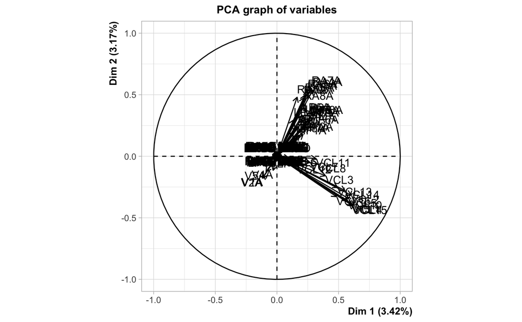

```r
plot.PCA(res.pca, choix = "var")
```

```r
# fviz_pca_var(res.pca)
```

- Conclusions: this plot shows the correlation between variables and the principal components. Variables with high loadings on the same component are strongly correlated

## 5.5. Units Plot

```r
round(res.pca$ind$coord, 3)
```

```
        Dim.1  Dim.2  Dim.3  Dim.4  Dim.5
1       0.078 -1.477  0.551  3.210 -1.467
2       0.247 -0.318 -0.728 -3.317 -0.074
3      -0.879 -2.594  5.083  3.587 -1.186
4      -0.246  2.409 -3.221 -2.491 -2.019
5      -0.335  3.685  0.717  1.070 -1.022
6       0.553  0.298 -0.896 -1.108 -1.722
7       1.042  0.289 -1.656 -1.526  0.021
8       1.961  0.058 -0.677  0.647  1.379
9      -0.020 -1.187 -0.894 -1.325  0.897
10     -0.117 -1.575  0.543 -0.515 -0.515
11    -11.428  1.328 -1.786  0.921  5.450
12     -0.848 -1.464 -3.919 -0.545 -1.083
13      0.787 -0.145 -0.603 -1.530 -0.407
14      1.062 -1.233 -1.341 -0.780  1.932
```

[output cut: 187 more lines]

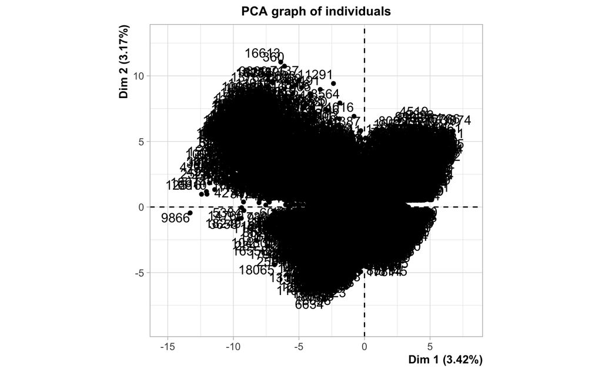

```r
plot.PCA(res.pca, choix = "ind")
```

- Conclusions: this plot visualizes the individuals in the principal component space, showing how they are distributed across the first two dimensions

## 5.6. Biplot

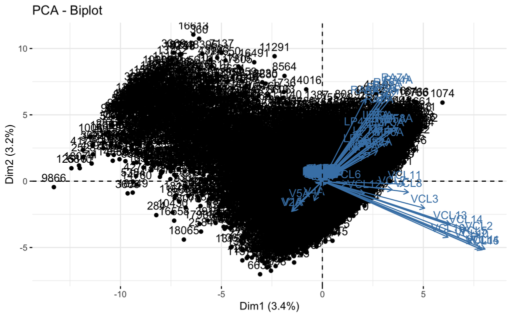

```r
fviz_pca_biplot(res.pca)
```

- Conclusions: the biplot combines the individuals and variables plots, providing a comprehensive view of the relationships in the data

## 5.7. Additional - Contributions of Variables to Dimensions (Dim1 & Dim2)

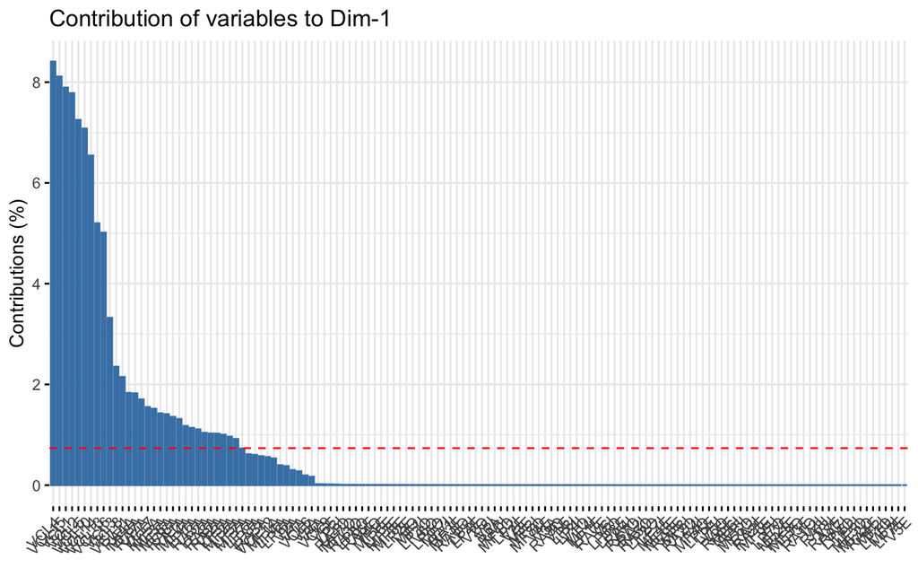

```r
fviz_pca_contrib(res.pca, choice = "var", axes = 1)
```

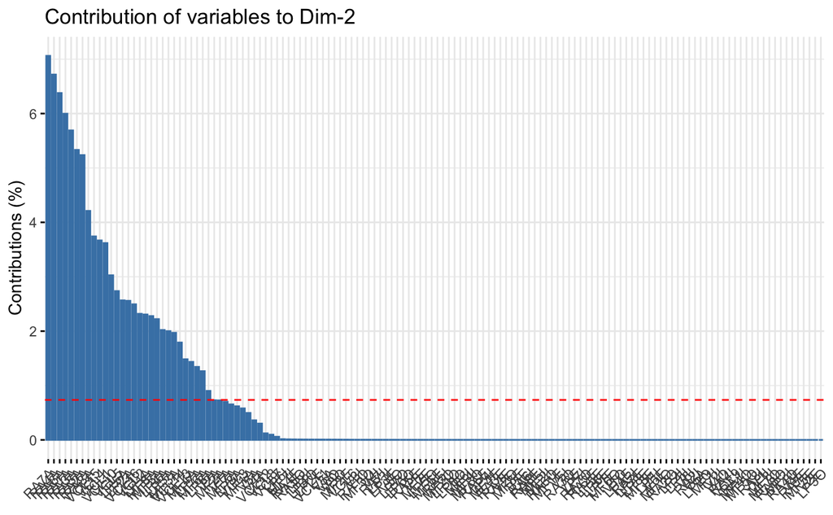

```r
fviz_pca_contrib(res.pca, choice = "var", axes = 2)
```

- Conclusions: these plots show which variables contribute most to the first two dimension